# Final Project Apple’s Quality

2024-04-28

## About the Dataset

- This dataset contains information about various attributes of apples, providing insights into their different characteristics and also information about their Quality as “Good/Bad”. The dataset is from an American agricultural company and taken from Kaggle.

```r
library(readr)
library(factoextra)
library(FactoMineR)
library(magrittr)
library(NbClust)
apples <- read.csv("D:/Rutgers/R2nd Semester/Multivariate/apple2.csv",row.names=1)
str(apples)
```

```
## 'data.frame':    51 obs. of  8 variables:
##  $ Size       : num  -3.97 -1.195 -0.292 -0.657 1.364 ...
##  $ Weight     : num  -2.51 -2.84 -1.35 -2.27 -1.3 ...
##  $ Sweetness  : num  5.346 3.664 -1.738 1.325 -0.385 ...
##  $ Crunchiness: num  -1.012 1.5882 -0.3426 -0.0979 -0.553 ...
##  $ Juiciness  : num  1.845 0.853 2.839 3.638 3.031 ...
##  $ Ripeness   : num  0.33 0.868 -0.038 -3.414 -1.304 ...
##  $ Acidity    : num  -0.492 -0.723 2.622 0.791 0.502 ...
##  $ Quality    : chr  "good" "good" "bad" "good" ...
```

```r
applesf <- apples[, c("Size", "Weight", "Crunchiness", "Sweetness", "Juiciness", "Ripeness", "Acidity")]
```

### Inference

- This is the data dictionary of the dataset:
- A_id: Unique identifier for each apple
- Size: Size of the fruit
- Weight: Weight of the fruit
- Sweetness: Degree of sweetness of the fruit
- Crunchiness: Texture indicating the crunchiness of the apple
- Juiciness: Level of juiciness of the fruit
- Ripeness: Stage of ripeness of the apple
- Acidity: Acidity level of the apple
- Quality: Overall quality of the apple
- The question posed was: Can we accurately predict the quality of a fruit based on its various measured attributes (Size, Weight, Sweetness, Crunchiness etc,.)? And can we identify key combinations or patterns that strongly influence quality?

### EDA Analysis

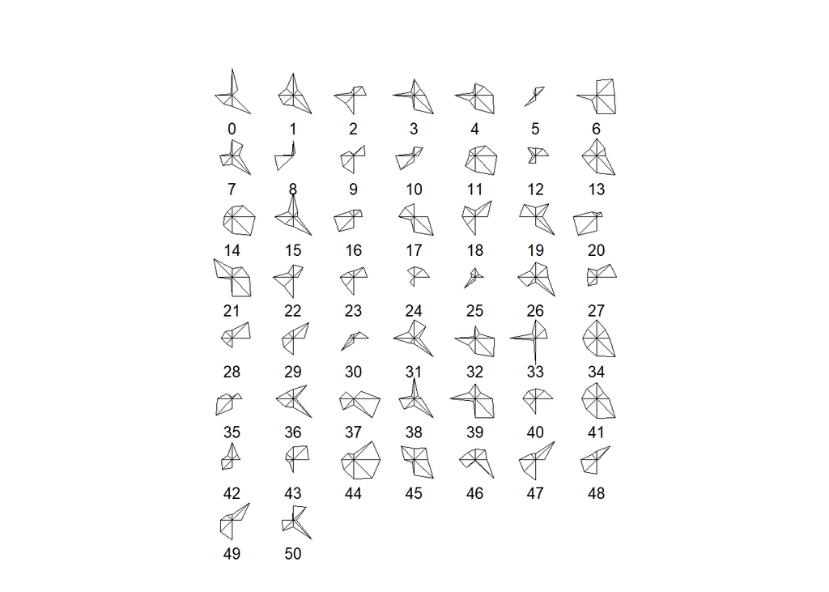

```r
stars(apples[,1:8])
```

### Inference

- Star plot helps us to check the similarity between the different apple’s quality.
- We can observe that few apples’s for example, 0,15 have similar characteristics which are influecing the quality of the apple.

### Corealtion plot

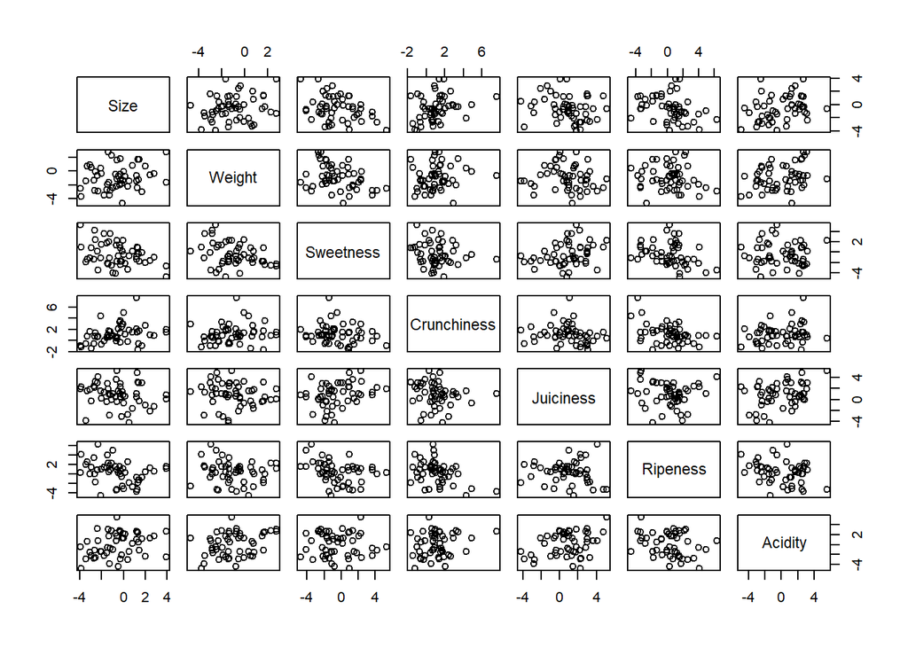

```r
pairs(apples[,1:7])
```